# Networks: structure, evolution & processes

**Internet Analytics - Lab 2**

**Group:** *Q*

**Names:**

- *Thomas Ecabert*
- *Luka Secilmis*
- *Aymeric Bacuet*
- *Berkay Güler*

```python
import networkx as nx
import matplotlib.pyplot as plt
import numpy as np
```

## 2.1 Exploration of real networks

#### Exercise 2.1

```python
# Open the network1 csv file in read mode
data = open('../data/network1.csv', "r")

# We create our nx Graph from this file
G = nx.parse_edgelist(data, comments='#', delimiter=',', create_using=nx.Graph(), nodetype=int)

print("Number of nodes:", G.number_of_nodes())
print("Number of edges:", G.number_of_edges())
```

```
Number of nodes: 13033
Number of edges: 18584
```

#### Exercise 2.2: Node degree distribution

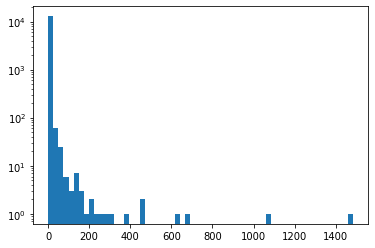

```
Mean node degree =  2.8518376429064682
Variance of node degree =  435.1334994620158
```

```python
# Create the array of the degree of all nodes

degrees = [G.degree[v] for v in G.nodes()]

# We use a log plot to visualize the degree distribution
plt.hist(degrees, bins = 60, log = True)
plt.show()

# Some properties of the degree distribution
m = np.mean(degrees)
print('Mean node degree = ', m)
print('Variance of node degree = ', np.var(degrees))
```

We used a log plot as there are a few values with very large node degrees.

```python
print(f'l = {1/m}')
```

```
l = 0.3506510977184675
```

#### Exercise 2.3: Giant component

```python
# Retrieve directly the number of connected components of our graph using networkx function
print(f"There are {nx.number_connected_components(G)} connected components")

# Compute the number of nodes in the giant component.
giant_comp_nodes = max(nx.connected_components(G), key=len)
print(f"There is indeed a giant component in our graph of size/number of nodes {len(giant_comp_nodes)}.")
print(f"This is a giant component as it contains {100* len(giant_comp_nodes) / G.number_of_nodes()}% of the nodes in G." )
```

```
There are 192 connected components
There is indeed a giant component in our graph of size/number of nodes 12576.
This is a giant component as it contains 96.49351645822144% of the nodes in G.
```

#### Exercise 2.4: Short paths & Small-worlds

```python
# Create the dictionnary of the shortest path lengths between any two nodes in our giant component
paths = dict(nx.all_pairs_shortest_path_length(G))
```

```python
# Sum all non-zero shortest path length in our dictionnary
path_lengths = []
for i in paths.values():
    for j in i.values():
        if j!=0:
            path_lengths.append(j)
```

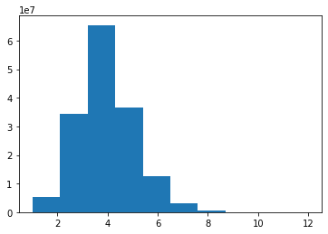

```python
# Distribution of path lengths between any two nodes in the network
plt.hist(path_lengths)
plt.show()
```

```python
# Average number of nodes reachable within a distance 6 (in number of hops) of any other node in the network
print(f'In our graph each node is connected by an average of only {np.mean(path_lengths)} degrees of seperation')
print('This clearly fits Duncan Watts definition as this is below 6.')
print(f'In fact {100 * len(np.argwhere(np.array(path_lengths) <= 6))/len(path_lengths)}% of nodes are reachable within a distance 6 of any other node in the network')
```

```
In our graph each node is connected by an average of only 4.175471997290978 degrees of seperation
This clearly fits Duncan Watts definition as this is below 6.
In fact 97.69441708262478% of nodes are reachable within a distance 6 of any other node in the network
```

#### Exercise 2.5: Network comparison

#### 2.5.1

```python
# Open the network1 csv file in read mode
data2 = open('../data/network2.csv', "r")

# We create our nx Graph from this file
G2 = nx.parse_edgelist(data2, comments='#', delimiter=',', create_using=nx.Graph(), nodetype=int)

print("Number of nodes:", G2.number_of_nodes())
print("Number of edges:", G2.number_of_edges())
```

```
Number of nodes: 26542
Number of edges: 43516
```

#### 2.5.2

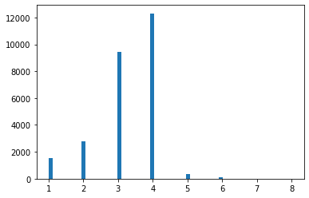

```
Mean node degree =  3.2790294627383014
Variance of node degree =  0.8129571169829002
```

```python
# Create the array of the degree of all nodes
degrees2 = [G2.degree(i) for i in G2.nodes]

# We visualize the degree distribution
plt.hist(degrees2, bins=60)
plt.show()

# Some properties of the degree distribution
m2 = np.mean(degrees2)
print('Mean node degree = ', m2)
print('Variance of node degree = ', np.var(degrees2))
```

#### 2.5.3

```python
# Retrieve directly the number of connected components of our graph using networkx function
print(f"There are {nx.number_connected_components(G2)} connected components")

# Compute the number of nodes in the giant component.
giant_comp_nodes_2 = max(nx.connected_components(G2), key=len)
print(f"There is indeed a giant component in our graph of size/number of nodes {len(giant_comp_nodes_2)}.")
print(f"This is a giant component as it contains {100* len(giant_comp_nodes_2) / G2.number_of_nodes()}% of the nodes in G." )
```

```
There are 5 connected components
There is indeed a giant component in our graph of size/number of nodes 26481.
This is a giant component as it contains 99.77017557079346% of the nodes in G.
```

#### 2.5.4

```python
# Create the dictionnary of the shortest path lengths between any two nodes in our giant component
paths_2 = dict(nx.all_pairs_shortest_path_length(G2))
```

```python
# Sum all non-zero shortest path length in our dictonnary
path_lengths_2 = []
for i in paths_2.values():
    for j in i.values():
        if j!=0:
            path_lengths_2.append(j)
```

```python
# As before we tried to plot the distribution of path lengths between any two nodes in the network
# However we waited for more than 30 minutes and it would still not terminate.
#plt.hist(path_lengths_2)
#plt.show()
```

```python
# Average number of nodes reachable within a distance 6 (in number of hops) of any other node in the network
print(f'In our graph each node is connected by an average of only {np.mean(path_lengths_2)} degrees of seperation')
print('This clearly fits Duncan Watts definition as this is below 6.')
print(f'In fact {100 * len(np.argwhere(np.array(path_lengths_2) <= 6))/len(path_lengths_2)}% of nodes are reachable within a distance 6 of any other node in the network')
```

[output not shown]

This network differs fom the first one in that, while the mean Node Degree is quite similar, the variance of the Node degrees is much much smaller than that of graph 1. In the first graph we have a few nodes that have huge degrees, but in the second graph this is not the case.

Furthermore there are less connected components in graph 2 than in graph 1. Graph 2 is dominated by one giant component more than graph 1.

Lastly, in contrast to graph 1, graph 2 is not a Small-World as 99.7 % of the nodes are not reachable within a distance 6 of any other node in the network - ie. it does not fit Duncan Watts definition.

#### Exercise 2.6: Network identification

We guess that newtork 1 is the subgraph of routers comprising the Internet, and that network 2 is the network of roads around the city of New-York. We guess this as first of all - it is impossible to have intersections with node degree of around 1000 in a city. Also we would expect this network to be dominated by one giant component more than the internet, as roads by definition and utility need to be connected. Furthemore it is logical that the roads around New York are not a Small-World since the road network is laid out in a grid pattern. To go from a point A to a point B in new york, we will have to go trough many intersections as the city is gridded and each intersection is only connected to its nearest intersections.